# 반려동물영양학-입/식도(Mouth/Esophagus)

February 5, 2018

in Animalsci

## 입(mouth)

입은 먹이가 처음으로 들어오는 곳입니다. 개와 고양이의 입은 가장 기본적인 목적인 먹이 섭취에 알맞은 구조로 되어 있습니다. 또한 입은 **먹이의 맛**을 느끼며, 씹는 행위를 통해 **물리적으로 분해**하고 먹이를 침과 잘 섞어 **식도로 넘깁니다.** 소나 양 같은 초식동물들이 돼새김질 등을 통해 먹이를 오래 씹어 삼키는 것과는 달리 개나 고양이는 비교적 큰 덩어리를 삼키는 경향이 있습니다. 또한 초식동물들에게 없는 **송곳니**가 있어 육식이 용이합니다.

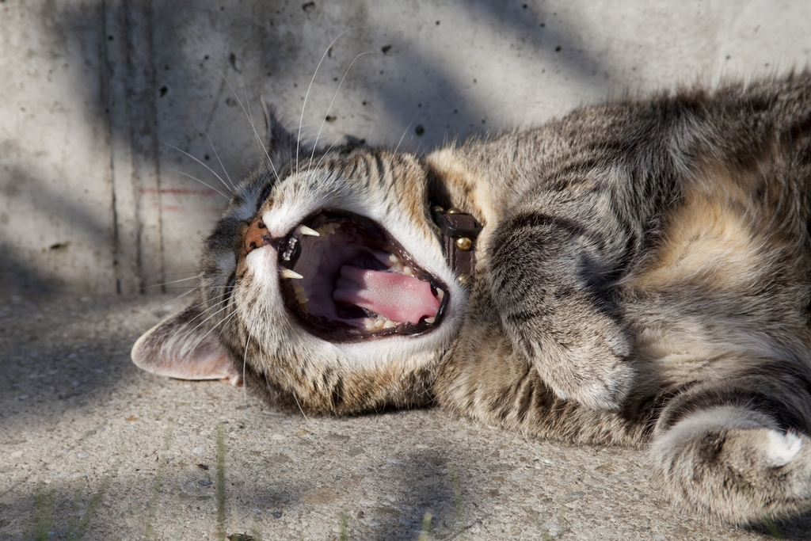

개와 고양이는 총 4쌍의 침샘을 갖고 있습니다. 침의 pH는 개의 경우 7.3 - 7.8, 고양이의 경우 약 7.5 정도입니다. 기본적으로 개와 고양이는 육식동물로 분류되기 때문에 침 내에 전분을 분해할 수 있는 α-amylase 분비량이 미미합니다. 또한 개의 경우 사람에 비해 땀샘이 덜 발달되어 있기 때문에 **침을 통한 열 발산**이 체온 조절에 매우 중요한 역할을 합니다. 개의 체온이 올라갈 경우, 부교감신경이 자극되고 사람의 10배 정도 되는 양의 많은 침을 분비하며 분비된 침과 함께 열도 함께 효율적으로 방출되게 됩니다.

개와 고양이는 혀에 있는 미뢰에 의해 맛을 느낄 수 있습니다. 개는 비교적 단맛을 잘 느끼는데 반해 고양이는 단맛을 잘 느끼지 못하며 오히려 퀴닌, 탄닌산 및 알칼로이드와 같이 쓴맛을 내는 물질을 좋아합니다. 이러한 사실은 개가 육식동물임에도 불구하고 과일이나 전분 등 단맛이 나는 음식을 좋아하는 것에 비해, 고양이는 비교적 육식만을 선호하는 사실로도 엿볼 수 있습니다.

## 식도(Esophagus)

입을 통해 들어온 먹이는 식도를 지나 위로 향합니다. 식도는 **연동운동을 통해 먹이를 이동**시키며 점액질을 분비하여 먹이의 이동을 돕습니다. 식도와 위가 연결되는 부분엔 열고 닫을 수 있는 괄약근(분문괄약근, cardiac sphincter)이 있는데, 이를 통하여 먹이를 위로 들여보내고 이동이 완료된 후 즉시 닫혀 위로부터 먹이가 역류하는 것을 막습니다.

## [목차]반려동물 영양학

[1. Introduction–영양학과 반려동물](https://youngjunna.github.io/2018/02/02/CANF-Introduction/)

[2. 입/식도–Mouth/Esophagus](https://youngjunna.github.io/2018/02/05/CANF-Mouth)